# 新闻和推文分析

Kang

## 概述

主要任务：

- 将新闻文本转换成csv文件。
- 分析每年或每个月的新闻或推文数量变化。
- 对所有新闻文本进行主题分析，解读出文本涉及的若干主题。
- 对新闻文本进行情感分析。
- 对部分推文文本进行主题分析。

## 数量变化

新闻每年和每个月数量变化如下。

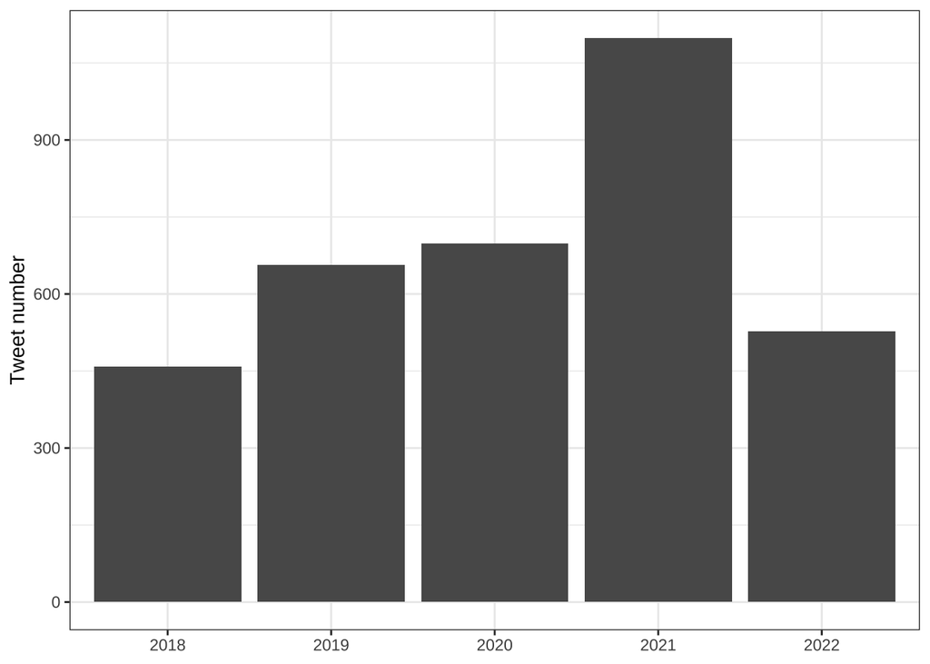

```r
# 每年新闻数量变化。
ash %>%
  group_by(year) %>%
  summarise(n = n(), .groups = "drop") %>%
  ggplot() +
  geom_col(aes(year, n)) +
  labs(x = NULL, y = "Tweet number") +
  theme_bw()
```

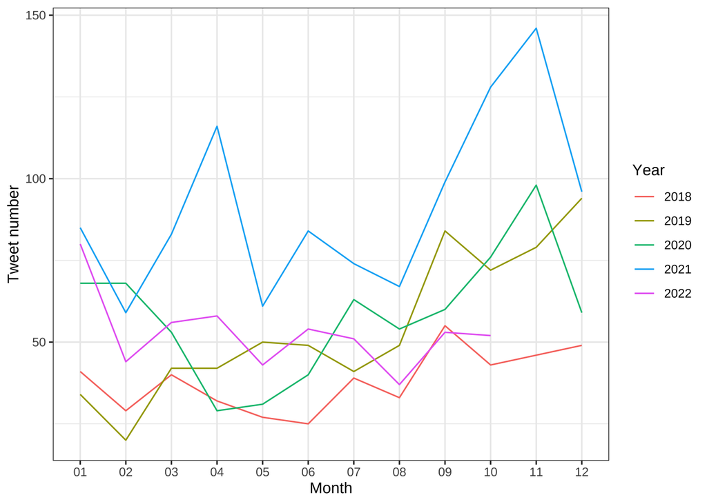

```r
# 每个月新闻数量变化。
ash %>%
  group_by(year, month) %>%
  summarise(n = n(), .groups = "drop") %>%
  ggplot() +
  geom_line(aes(month, n, col = year, group = year)) +
  labs(x = "Month", y = "Tweet number", col = "Year") +
  theme_bw()
```

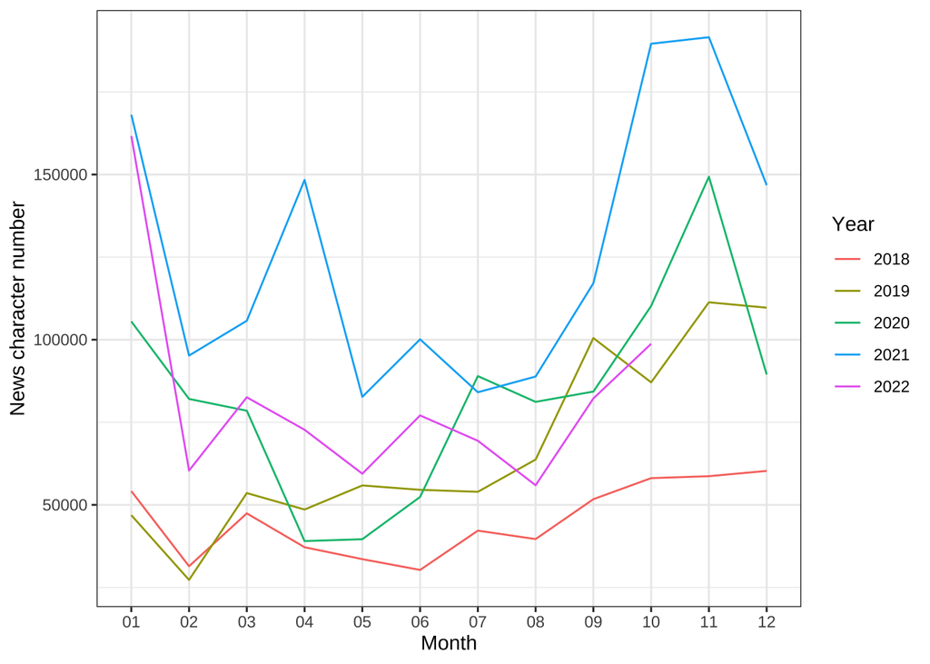

```r
# 每个月字数变化。
ash %>%
  group_by(year, month) %>%
  summarise(char_count = sum(char_count), .groups = "drop") %>%
  ggplot() +
  geom_line(aes(month, char_count, col = year, group = year)) +
  labs(x = "Month", y = "News character number", col = "Year") +
  theme_bw()
```

新闻每月数量和字数之间高度相关：

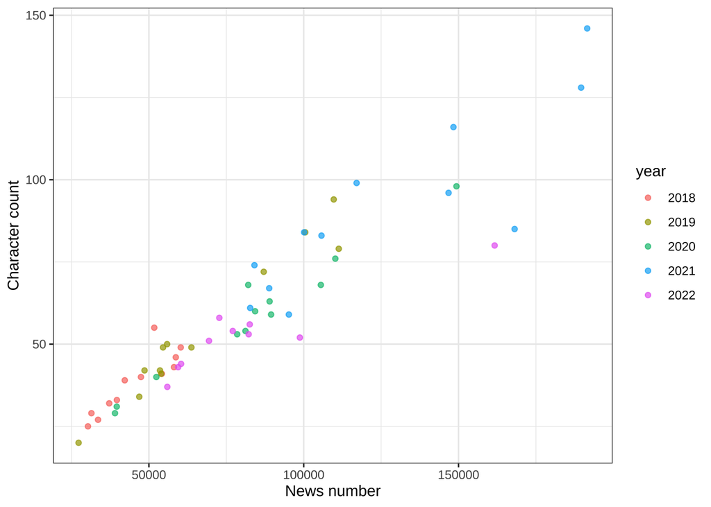

```r
news_mth_n_char %>%
  ggplot() +
  geom_point(aes(char_count, n, col = year), alpha = 0.7) +
  labs(x = "News number", y = "Character count") +
  theme_bw()
```

```r
cor.test(news_mth_n_char$n, news_mth_n_char$char_count)
```

```
##
##  Pearson's product-moment correlation
##
## data:  news_mth_n_char$n and news_mth_n_char$char_count
## t = 20.122, df = 56, p-value < 2.2e-16
## alternative hypothesis: true correlation is not equal to 0
## 95 percent confidence interval:
##  0.8958734 0.9625485
## sample estimates:
##       cor
## 0.9372819
```

推文每月数量变化：

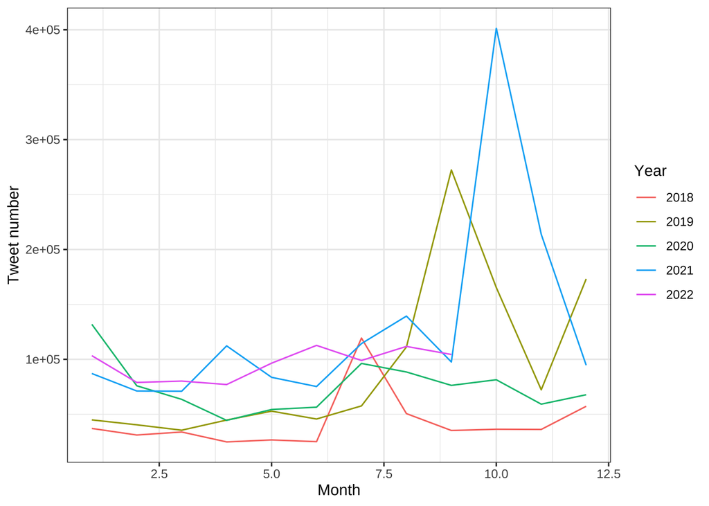

```r
general_plot_dt %>%
  mutate(year = year(date), month = month(date)) %>%
  group_by(year, month) %>%
  summarise(tw_num = sum(tw_num), .groups = "drop") %>%
  ggplot() +
  geom_line(aes(month, tw_num, col = as.character(year), group = year)) +
  labs(x = "Month", y = "Tweet number", col = "Year") +
  theme_bw()
```

## 主题分析

文本分析的基本流程为：

（1）先读取所有新闻（我们称每条新闻为”文档”）。

（2）将每个文档进行分词。

（3）去除停止词。

（4）统计词语的频率，同时也可以计算词语的重要性（TF-IDF方法）。

（5）用主题模型对各个文档进行归类，结果呈现为每个文档被划分到各个主题的概率，例如，如果我们希望所有文档被归入3个主题中，那么某个文档属于主题1、2、3的概率可能分别是0.8、0.1、0.1。

用LDA方法对文本进行主题分析，需要先定义主题数量。如果主题数量很少，例如极端情况下（理论上并不合理），我们将所有文档只归入1个主题中，那么所有文档属于该主题的概率就是100%，这种主题划分就没有意义了；再往前一步，如果分成2个主题，如果文档之间有很好的区分度，那没有问题，但是也可能出现大部分文档归入两个主题的概率都差不多是50%，区分度不够高；反之，如果我们将n个文档归入将近n个主题，那每个文档肯定会有所属概率更高的主题类别，但是主题太多，归类的意义也就小了。因此，在定义主题数量的时候，我们希望尽量少，但是又有足够的区分度。

```r
# 图形参考之前的报告。
```

```r
# 图形参考之前的报告。
```

用LDA将文本分成8个主题，各个主题的关键词如下。可见还有些词需要合并或者去除。

```r
library(knitr)
library(kableExtra)
topic_word %>%
  kable() %>%
  kable_styling()
```

| topic | term |
| --- | --- |
| 1 | 市, 化, 県, 温暖, 約, 影響, 度, 気象, 水, 被害, 観測, 台風, 気温, 人, 災害, 大, 研究, 気候, 地域, 豪雨, 上昇, 地球, きた, 的, 海, 氷, 以上, メートル, 変動, 日本 \| |
| 2 | 排出, 化, 目標, 国, 日本, ガス, 石炭, エネルギー, 環境, 対策, 気候, 温暖, 削減, 的, 効果, 量, 温室, 原発, 世界, 発電, 炭素, 脱, 電力, 企業, 政府, 変動, ゼ, ロ, 約, 再 \| |
| 3 | 的, 社会, 人, 経済, 日本, 企業, コロナ, 国, 者, 世界, 問題, 化, 必要, たち, 感染, 大学, 課題, 対策, できる, 支援, 成長, 性, 力, 環境, 投資, 考え, 政府, 政策, 危機, 進 \| |
| 4 | 人, たち, 東京, 日本, 見, 五輪, 市, 環境, 歳, 世界, 者, 活動, 化, 県, 感じ, 写真, たい, きた, 参加, 家, 気候, 思, 地球, できる, 的, 食, 会, 若者, 子ども, 考え \| |
| 5 | 的, 研究, 科学, 化, 地球, 大, 世界, 日本, 人, 者, ごみ, プラスチック, 技術, たち, 教授, 問題, 環境, 人間, できる, 人類, 使, 温暖, 社会, 大学, 賞, 開発, きた, 宇宙, 学, 気候 \| |
| 6 | 氏, 党, トランプ, 大統領, 人, 選挙, 首相, 選, 者, 政治, 政権, 民主, 支持, 政策, ン, 米, デ, 院, バイ, 州, 米国, 議員, 対策, 会, 面, 的, 派, 化, 投票, 問題 \| |
| 7 | 中国, 米, 米国, 国, 的, 氏, ン, デ, 政権, 国際, バイ, 日本, 大統領, 世界, 問題, 首脳, 関係, 気候, トランプ, 経済, 変動, ロシア, 欧州, 協力, 首相, 会談, 会議, 外交, 政府, 安全 \| |
| 8 | 環境, 原発, 日本, 生物, 世界, 地球, 自然, 大, 海, 性, 写真, 東京, 開発, 多様, 森林, 教授, たち, 事故, 問題, 保護, 者, 研究, コーディネーター, 国際, 社会, 的, 可能, 持続, 本社, 気候 \| |

选取各主题典型文本：

```r
topic_text %>%
  kable() %>%
  kable_styling()
```

[output not shown]

计算各个主题的显著度，2022年1-6月（和下面推文主题分析的时间一致）各主题显著度随着时间变化如下：

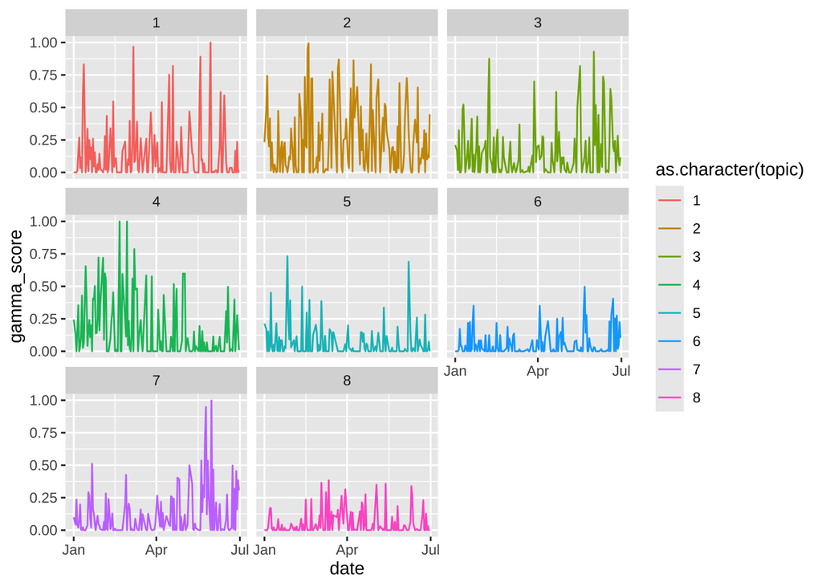

```r
quan_id_topic %>%
  mutate(
    year = substr(date, 1, 4),
    month = substr(date, 6, 7) %>% as.numeric(),
    day = substr(date, 9, 10),
    date = as_date(paste(year, month, day, sep = "-"))
  ) %>%
  filter(year == "2022", month <= 6) %>%
  group_by(date, topic) %>%
  summarise(gamma = sum(gamma), .groups = "drop") %>%
  group_by(date) %>%
  mutate(tot_gamma = sum(gamma), gamma_score = gamma / tot_gamma) %>%
  ggplot() +
  geom_line(aes(date, gamma_score, col = as.character(topic), group = topic)) +
  facet_wrap(.~ topic)
```

同样地，对推文进行主题分析。由于推文数量太多，只选取2022年1-6月，每个月份1000条推文进行分析。同样拆分成8个主题。

```r
topic_word_2022 %>%
  kable() %>%
  kable_styling()
```

| topic | term |
| --- | --- |
| 1 | 温暖化, 地球温暖化, さい, 地球, くだ, 取り組む, 人, 思, 対策, 一人, 言, 影響, 名, 選, 聞, 投稿, よね, もう, 気, フォロー, 抽選, プレゼント, 締切, 景品, 人間, 今, 起, 自然, 変化, 話 \| |
| 2 | 地球温暖化, 温暖化, 市, 進む, 為, 高, 環境, ソーラー, 氏, はい, 森林伐採, 設置, メガ, 対策, ガス, 大臣, 削減, エネルギー, 論, エ, ネ, 原発, 肉, 再, 動画, 国際, 日本, 出, ロシア, ニュース \| |
| 3 | 温暖化, 地球温暖化, 日本, 気温, 脱, 影響, 防止, 度, 東京, コード, 以上, 対策, 炭素, 時間, 大雪, データ, 気象, 猛暑, 倍, グレタ, 北海道, 観測, 勢力, 増加, 大, パネル, 世界, 塩, 無力, 今日 \| |
| 4 | 温暖化, 地球温暖化, 対策, 水, 日本, エネルギー, 体温, 地域, 環境, 的, 地球, 気候変動, えて, 未来, 影響, 国, 危機, 高温, 可能, 原発, さい, 維新, 政策, なん, 食, 問題, 化, 企業, 気候, 産業 \| |
| 5 | 地球温暖化, 温暖化, 円, 環境, せい, 対策, 税, 地球, 加速, たり, ー, ちゃん, 人, レ, たい, お願い, スイッチ, 今, 使い, 目, 皆様, ガソリン, 質問, 嘘, 毎日, 洗濯, 管理, 人間, 用品, 要因 \| |
| 6 | 温暖化, 地球温暖化, 世界, メディア, シロクマ, 言, ツバル, 頭, 先生, 東大, 教授, 国, 万, 正, 詐欺, 連, 渡辺, 歳, 使, 利権, 沈, 名誉, 絶滅, 情報, なのに, いま, 取り上げ, 作, 減少, われ \| |
| 7 | 地球温暖化, 原発, 汚染, 地球, 温暖化, 原因, 剤, 大気, 人類, 最大, 寒冷化, 大, 環境, 化, 起, 農薬, 基, 人, 等, アース, 世界, 電気, 自動車, ハウス, 対策, 化学, 経済, 削減, 問題, 性 \| |
| 8 | 温暖化, 地球温暖化, 太陽光, 発電, 詐欺, 日本, 騙, 原発, 日本人, 億, チン, エネルギー, プー, 原子力, 対策, 石炭, くらい, 問題, 暴露, 噴火, ン, 電力, 欧州, 火山, ワクチン, 炭素, 環境, ドル, ガス, 的 \| |

推文各个主题的显著度变化：

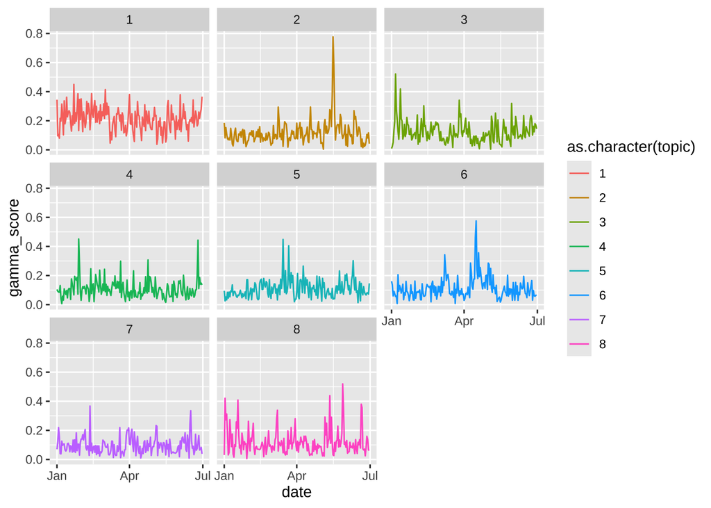

```r
tw_id_topic %>%
  group_by(date, topic) %>%
  summarise(gamma = sum(gamma), .groups = "drop") %>%
  group_by(date) %>%
  mutate(tot_gamma = sum(gamma), gamma_score = gamma / tot_gamma) %>%
  ggplot() +
  geom_line(aes(date, gamma_score, col = as.character(topic), group = topic)) +
  facet_wrap(.~ topic)
```

## 情感分析

新闻情感分析结果中，各个词语的极性如下。

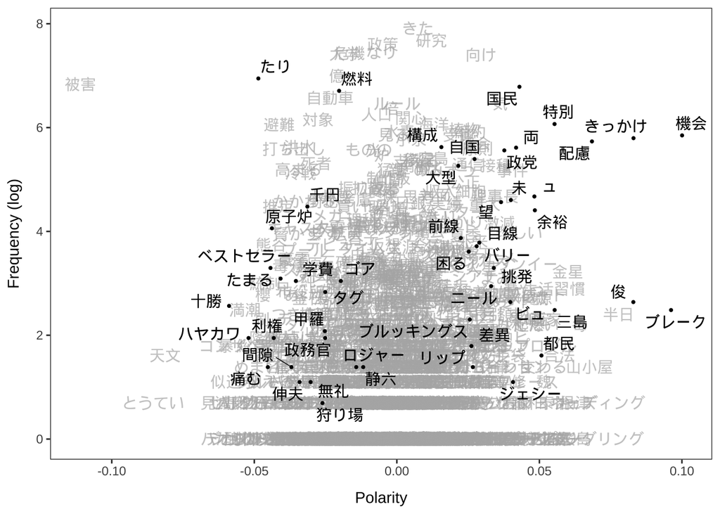

```r
textplot_terms(lss)
```

新闻情感随着时间的变化如下：

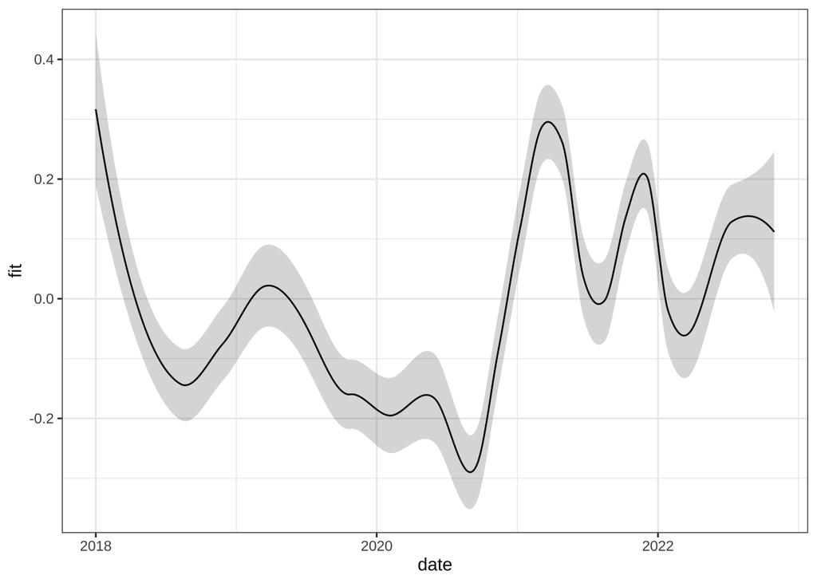

```r
ggplot(lss_score_smooth) +
  geom_line(aes(date, fit)) +
  geom_ribbon(aes(x = date, ymin = fit - se, ymax = fit + se), alpha = 0.2) +
  theme_bw()
```